# Heart Disease

Allen Samuel Christopher C00290834

05/1/2022

# 1 Introduction

This dataset contains information about contains diagnoses of heart disease patients. Every day, the average human heart beats around 100,000 times, pumping 2,000 gallons of blood through the body. Inside your body there are 60,000 miles of blood vessels.

The signs of a woman having a heart attack are much less noticeable than the signs of a male. In women, heart attacks may feel uncomfortable squeezing, pressure, fullness, or pain in the center of the chest. It may also cause pain in one or both arms, the back, neck, jaw or stomach, shortness of breath, nausea and other symptoms. Men experience typical symptoms of heart attack, such as chest pain , discomfort, and stress. They may also experience pain in other areas, such as arms, neck , back, and jaw, and shortness of breath, sweating, and discomfort that mimics heartburn.

It’s a lot of work for an organ which is just like a large fist and weighs between 8 and 12 ounces.

# 2 Research Question:

- How is the heart impacted cholesterol, Resting Blood pressure, maximum heart rate, Depression Rate,etc ?.

# 3 Data Description

[Dataset source](https://archive.ics.uci.edu/ml/datasets/Heart+Disease)

The dataset was created by: -  
1. Hungarian Institute of Cardiology. Budapest: Andras Janosi, M.D.  
2. University Hospital, Zurich, Switzerland: William Steinbrunn, M.D.  
3. University Hospital, Basel, Switzerland: Matthias Pfisterer, M.D.  
4. V.A. Medical Center, Long Beach and Cleveland Clinic Foundation: Robert Detrano, M.D., Ph.D.

columns:

age: The person’s age in years  
sex: The person’s sex (1 = male, 0 = female)  
cp: chest pain type  
— Value 0: asymptomatic — Value 1: atypical angina — Value 2: non-anginal pain — Value 3: typical angina  
trestbps: The person’s resting blood pressure (mm Hg on admission to the hospital)  
chol: The person’s cholesterol measurement in mg/dl  
fbs: The person’s fasting blood sugar (> 120 mg/dl, 1 = true; 0 = false)  
restecg: resting electrocardiographic results  
— Value 0: showing probable or definite left ventricular hypertrophy by Estes’ criteria — Value 1: normal - Value 2: having ST-T wave abnormality (T wave inversions and/or ST elevation or depression of > 0.05 mV)  
thalach: The person’s maximum heart rate achieved  
exang: Exercise induced angina (1 = yes; 0 = no)  
oldpeak: ST depression induced by exercise relative to rest (‘ST’ relates to positions on the ECG plot. See more here)  
slope: the slope of the peak exercise ST segment — 0: downsloping; 1: flat; 2: upsloping  
0: downsloping; 1: flat; 2: upsloping  
ca: The number of major vessels (0–3)  
thal: A blood disorder called thalassemia Value 0: NULL (dropped from the dataset previously  
Value 1: fixed defect (no blood flow in some part of the heart) Value 2: normal blood flow Value 3: reversible defect (a blood flow is observed but it is not normal)  
target: Heart disease (1 = no, 0= yes)

```r
glimpse(data)
```

```
## Rows: 303
## Columns: 15
## $ S.NO     <int> 1, 2, 3, 4, 5, 6, 7, 8, 9, 10, 11, 12, 13, 14, 15, 16, 17, 18…
## $ age      <int> 63, 37, 41, 56, 57, 57, 56, 44, 52, 57, 54, 48, 49, 64, 58, 5…
## $ sex      <int> 1, 1, 0, 1, 0, 1, 0, 1, 1, 1, 1, 0, 1, 1, 0, 0, 0, 0, 1, 0, 1…
## $ cp       <int> 3, 2, 1, 1, 0, 0, 1, 1, 2, 2, 0, 2, 1, 3, 3, 2, 2, 3, 0, 3, 0…
## $ trestbps <int> 145, 130, 130, 120, 120, 140, 140, 120, 172, 150, 140, 130, 1…
## $ chol     <int> 233, 250, 204, 236, 354, 192, 294, 263, 199, 168, 239, 275, 2…
## $ fbs      <int> 1, 0, 0, 0, 0, 0, 0, 0, 1, 0, 0, 0, 0, 0, 1, 0, 0, 0, 0, 0, 0…
## $ restecg  <int> 0, 1, 0, 1, 1, 1, 0, 1, 1, 1, 1, 1, 1, 0, 0, 1, 1, 1, 1, 1, 1…
## $ thalach  <int> 150, 187, 172, 178, 163, 148, 153, 173, 162, 174, 160, 139, 1…
## $ exang    <int> 0, 0, 0, 0, 1, 0, 0, 0, 0, 0, 0, 0, 0, 1, 0, 0, 0, 0, 0, 0, 0…
## $ oldpeak  <dbl> 2.3, 3.5, 1.4, 0.8, 0.6, 0.4, 1.3, 0.0, 0.5, 1.6, 1.2, 0.2, 0…
## $ slope    <int> 0, 0, 2, 2, 2, 1, 1, 2, 2, 2, 2, 2, 2, 1, 2, 1, 2, 0, 2, 2, 1…
## $ ca       <int> 0, 0, 0, 0, 0, 0, 0, 0, 0, 0, 0, 0, 0, 0, 0, 0, 0, 0, 0, 2, 0…
## $ thal     <int> 1, 2, 2, 2, 2, 1, 2, 3, 3, 2, 2, 2, 2, 2, 2, 2, 2, 2, 2, 2, 3…
## $ target   <int> 1, 1, 1, 1, 1, 1, 1, 1, 1, 1, 1, 1, 1, 1, 1, 1, 1, 1, 1, 1, 1…
```

Cleaning the unwanted DATA.

Installing naniar Package. if there is any missing values it will automatically plot and shows the missing values. For instance : In this data set there is no missing values so its showing as 0 %

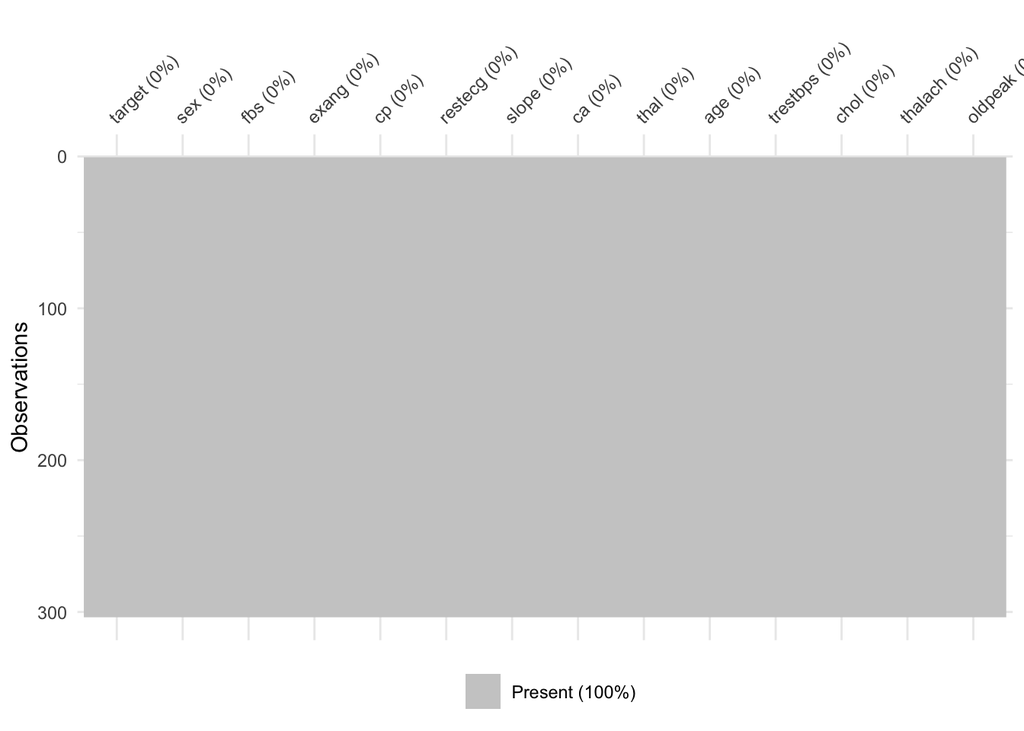

```r
#install.packages("naniar")
library(naniar)

vis_miss(data2)
```

[figure not shown]

```r
boxplot(data[,10:14])
```

## 3.1 Analysis of presence and Absence of Heart Disease.

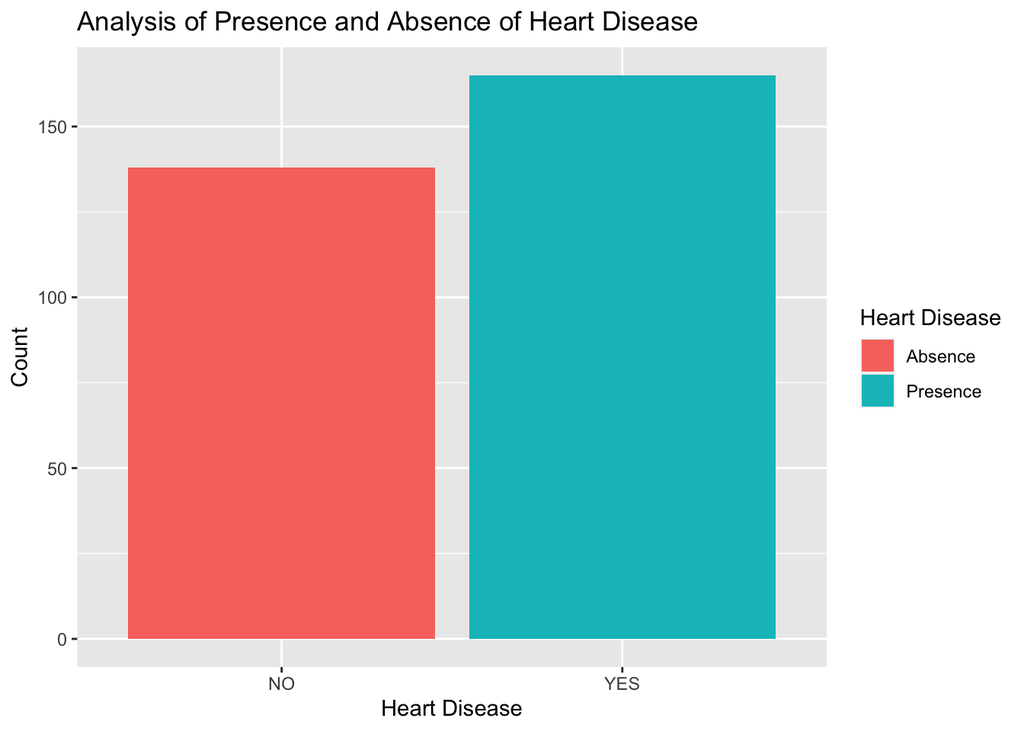

```r
graph1 <- ggplot(data2, aes(x=data2$target, fill=data2$target)) +
  geom_bar() +
  xlab("Heart Disease") +
  ylab("Count") +
  ggtitle("Analysis of Presence and Absence of Heart Disease") +
  scale_fill_discrete(name = "Heart Disease", labels = c("Absence", "Presence"))

graph1
```

## 3.2 Analysis of Chest Pain Experienced.

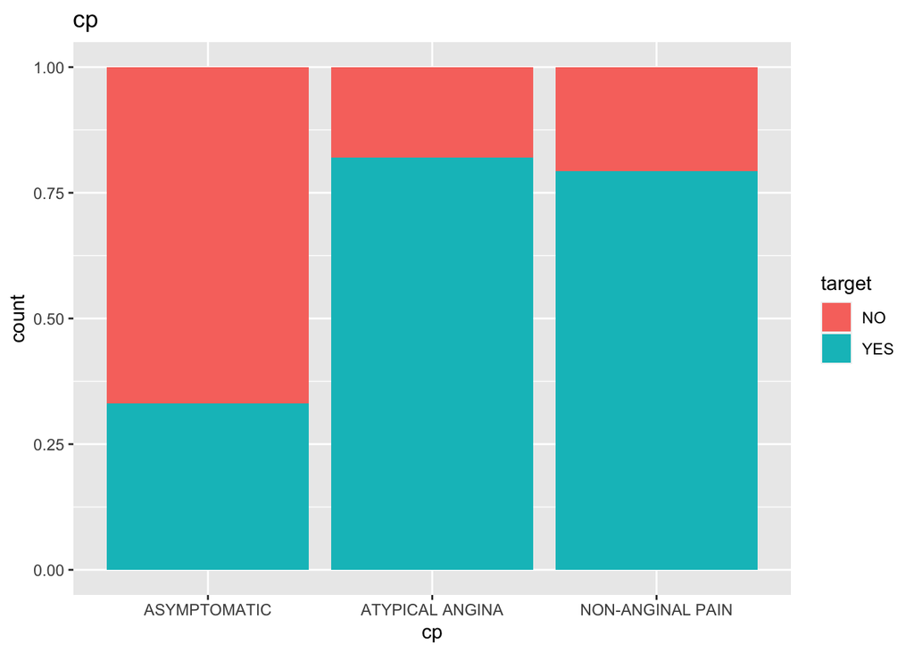

```r
graph2 <- ggplot(data2, aes(cp, fill = target))+
  geom_bar(position = "fill")+
  ggtitle("cp")
graph2
```

The above plot shows whether and what type of chest pain did target(patient) had.  
Insights  
Atypical and Non Anginal chest pain can be seen in more than two-thirds of targets

## 3.3 Age variable Analysis

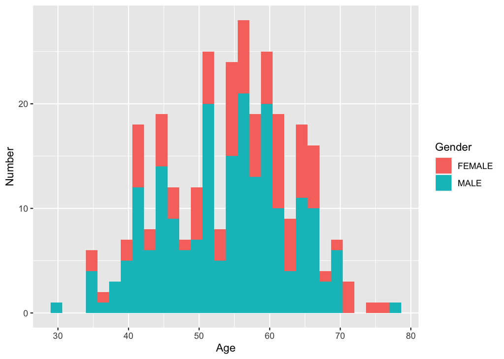

```r
#Distribution of Male and Female population across Age parameter
data2 %>%
  ggplot(aes(x=age,fill=sex))+
  geom_histogram()+
  xlab("Age") +
  ylab("Number")+
  guides(fill = guide_legend(title = "Gender"))
```

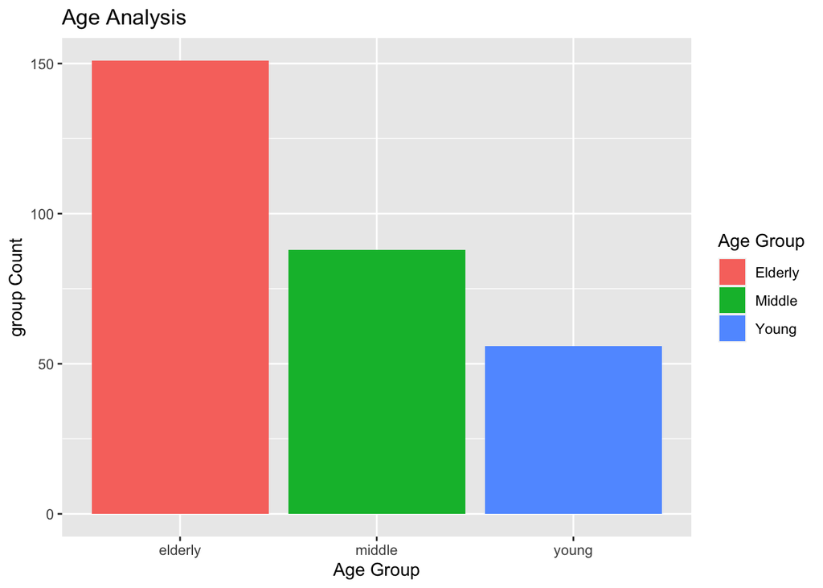

```r
# Group the different ages in three groups (young, middle, old)
young <- data[which((data$age<45)), ]
middle <- data[which((data$age>=45)&(data$age<55)), ]
elderly <- data[which(data$age>55), ]
groups <- data.frame(age_group = c("young","middle","elderly"), group_count = c(NROW(young$age), NROW(middle$age), NROW(elderly$age)))

#ploting different age groups
ggplot(groups, aes(x=groups$age_group, y=groups$group_count, fill=groups$age_group)) +
  ggtitle("Age Analysis") +
  xlab("Age Group")  +
  ylab("group Count") +
  geom_bar(stat="identity") +
  scale_fill_discrete(name = "Age Group", labels = c("Elderly", "Middle", "Young"))
```

## 3.4 Representation of Cholestoral level

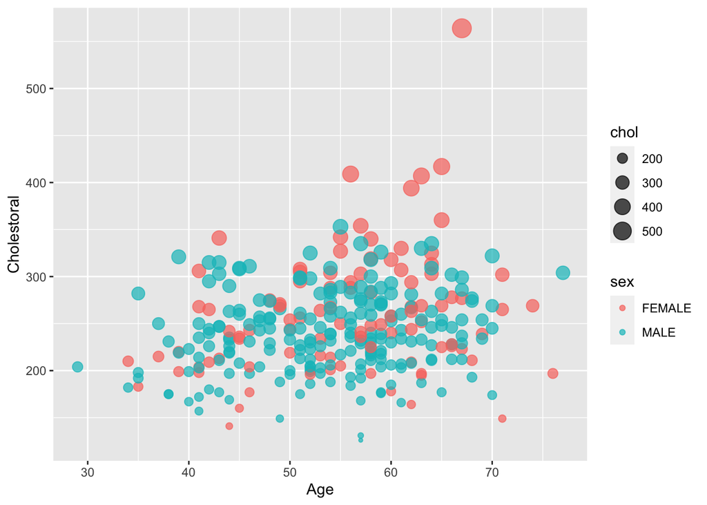

```r
# Representation of Cholestoral level

data2 %>%
  ggplot(aes(x=age,y=chol,color=sex, size=chol))+
  geom_point(alpha=0.7)+xlab("Age") +
  ylab("Cholestoral")+
  guides(fill = guide_legend(title = "Gender"))
```

## 3.5 Analysis of maximum heart rate achieved

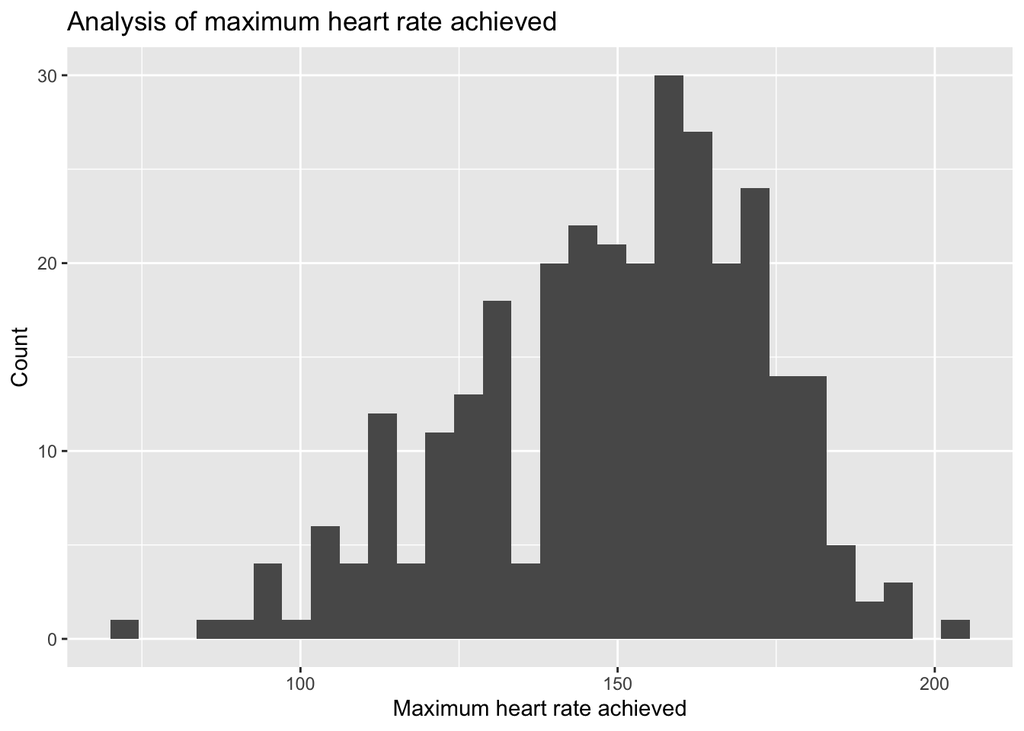

```r
# Histogram for thalach (maximum heart rate achieved)
ggplot(data, aes(x=thalach)) +
geom_histogram() +
  xlab("Maximum heart rate achieved") +
  ylab("Count") +
  ggtitle("Analysis of maximum heart rate achieved")
```

From the above histogram, we can analyse that the data is now normally distributed but we can also observe that outliers are present in the data. So, we remove the outliers from the data.

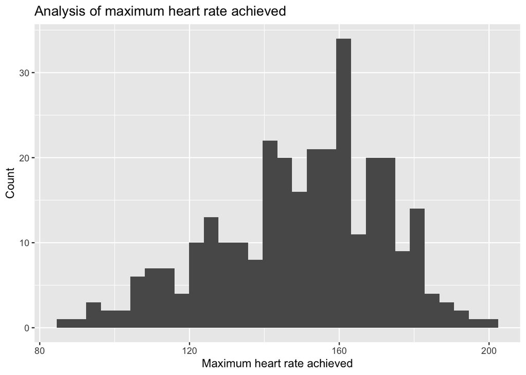

```r
# Replacing the outlier value with median value of thalach
data$thalach = ifelse(data$thalach < 75, NA, data$thalach)
data$thalach = ifelse(is.na(data$thalach), median(data$thalach[which(!is.na(data$thalach))]), data$thalach)

ggplot(data, aes(x=thalach)) +
  geom_histogram() +
  xlab("Maximum heart rate achieved") +
  ylab("Count") +
  ggtitle("Analysis of maximum heart rate achieved")
```

After the outlier replacement we can analyse that the data is now normally distributed.

## 3.6 Finding Age of the Gender

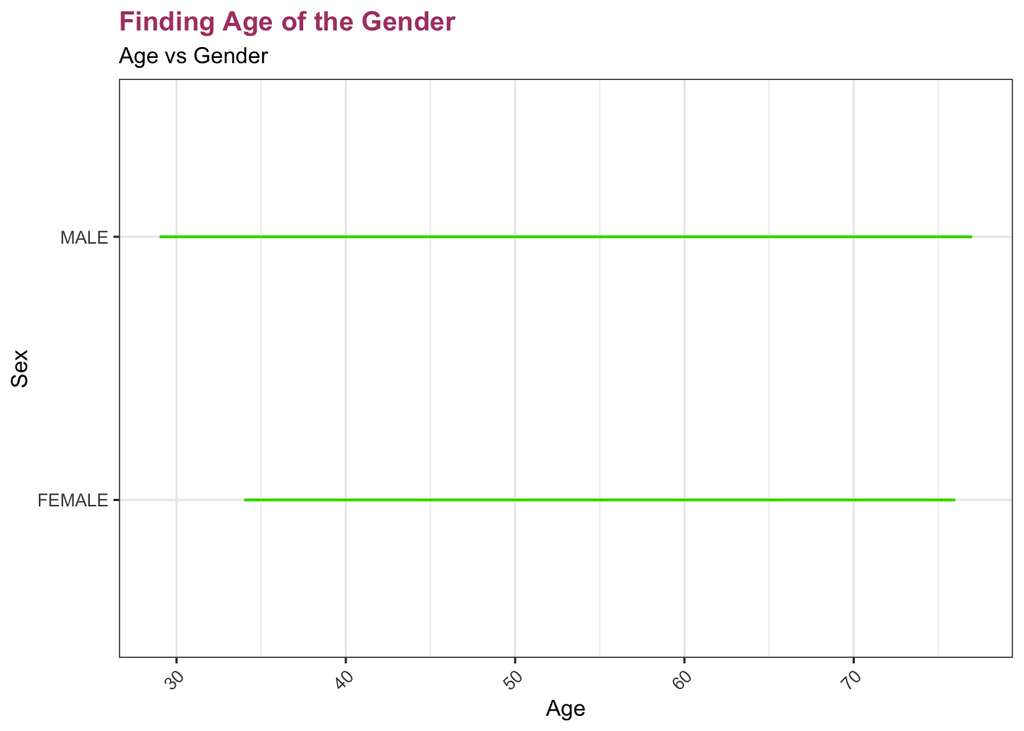

```r
plot1 <- data2 %>%

  ggplot(aes(age,sex))+ geom_line(colour = "green", size = 0.7)+
  geom_smooth(method = 'loess',colour = "Red", se = FALSE, size = 0.1)+
  theme_bw()+
  theme(
      axis.text.x = element_text(angle = 45,hjust = 1,vjust = 1),
      legend.position = "top",
      plot.title = element_text(face = "bold", colour = "#AE4371")
  )+
  labs(
    title = "Finding Age of the Gender",
    subtitle = "Age vs Gender",
    x = "Age",
    y = "Sex",
  )

plot1
```

Insights

## 3.7 Comparing Age with other factors.

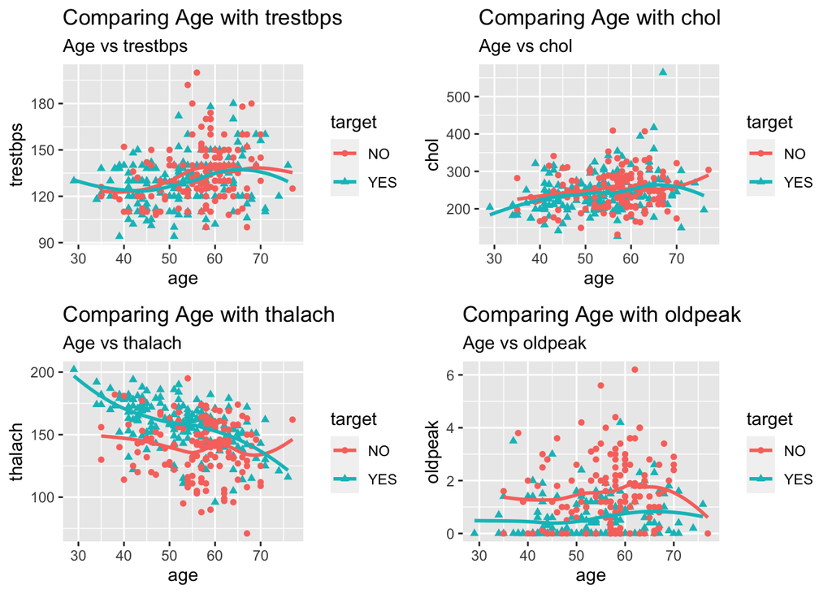

```r
#install.packages("ggpubr")
library(ggpubr)
plot1 <- ggplot(data2, aes(x = age, y = trestbps, color = target, shape = target))+
  geom_point()+
  geom_smooth(se = FALSE)+ labs(
    title = "Comparing Age with trestbps",
    subtitle = "Age vs trestbps",
    x = "age",
    y = "trestbps")

plot2 <- ggplot(data2, aes(x = age, y = chol, color = target, shape = target))+
  geom_point()+
  geom_smooth(se = FALSE)+ labs(
    title = "Comparing Age with chol",
    subtitle = "Age vs chol",
    x = "age",
    y = "chol")

plot3 <- ggplot(data2, aes(x = age, y = thalach, color = target, shape = target))+
  geom_point()+
  geom_smooth(se = FALSE)+ labs(
    title = "Comparing Age with thalach",
    subtitle = "Age vs thalach",
    x = "age",
    y = "thalach")

plot4 <- ggplot(data2, aes(x = age, y = oldpeak, color = target, shape = target))+
  geom_point()+
  geom_smooth(se = FALSE) + labs(
    title = "Comparing Age with oldpeak",
    subtitle = "Age vs oldpeak",
    x = "age",
    y = "oldpeak")

ggarrange(plot1, plot2, plot3, plot4 ,ncol =2, nrow = 2, align = 'h')
```

trestbps = The person’s resting blood pressure (mm Hg on admission to the hospital)  
Comparing Age with trestbps  
From the above graph we can interpret the person who is having resting blood pressure level above 120 and people who are aged from 50 to 70 are mostly not having heart disease. The people who are aged from 30 to 40 are mostly impacted by heart disease.  
Chol = The person’s cholesterol measurement in mg/d  
Comparing Age with Chol  
From the above graph we can interpret the person who is having cholesterol level from 200 to 350 and people who are aged from 60 to 70 are mostly not impacted with heart disease. he people who are aged from 28 to 50 are mostly prone to heart disease.  
oldpeak = ST depression induced by exercise relative to rest  
Comparing Age with oldpeak The person who has ST depression level from 0.6 to 6 are likely not been affected from heart Disease.  
thalach: The person’s maximum heart rate achieved  
The people who are aged between 30 to 55 and whose heart rate levels above 150 are more prone to heart Disease.

## 3.8 Pain analysis Using Box plot and categorized with Gender

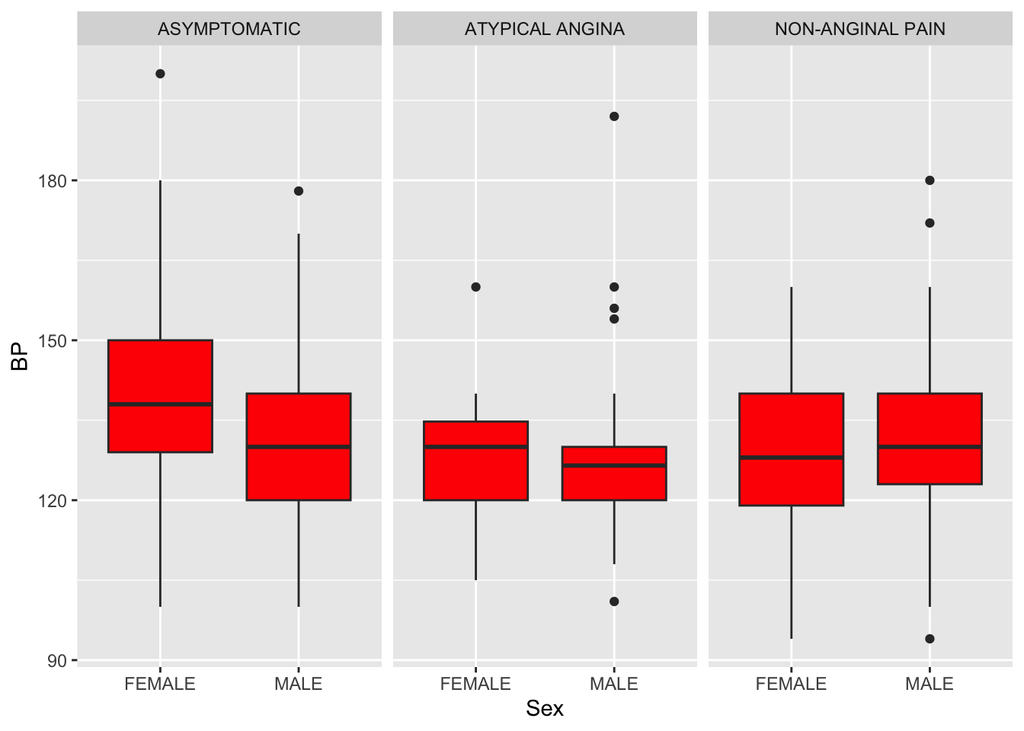

```r
plot1 <- data2 %>%
  ggplot(aes(x=sex,y=trestbps))+
  geom_boxplot(fill="red")+
  xlab("Sex")+
  ylab("BP")+
  facet_grid(~cp)
plot1
```

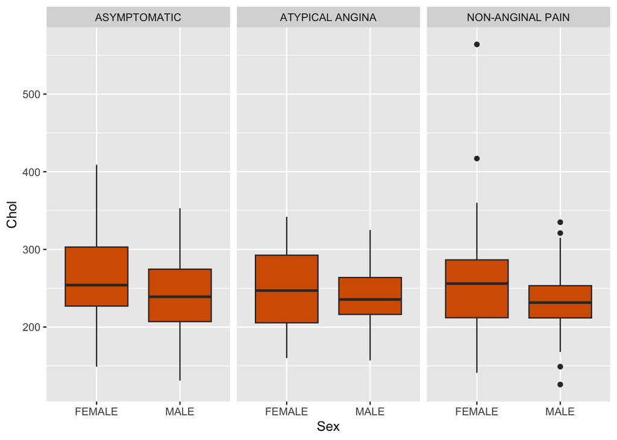

```r
plot2 <- data2 %>%
  ggplot(aes(x=sex,y=chol))+
  geom_boxplot(fill="#D55E00")+
  xlab("Sex")+
  ylab("Chol")+
  facet_grid(~cp)

plot2
```